# Who are the Twitter trolls harrassing Linda Sarsour?

Christina Chang

5/20/2018

*cchang[at]mpp.hertie-school.org*

*Data journalism project for Web Data Collection and Social Media Mining course at the Hertie School of Governance.*

In the Trump era, racist online abuse is on the rise. Learn how data mining from the Twitter stream can help you identify the most influential trolls and how you can take action to reduce prejudiced behaivor online.

Last year, the [Pew Research Center](http://assets.pewresearch.org/wp-content/uploads/sites/14/2017/07/10151519/PI_2017.07.11_Online-Harassment_FINAL.pdf) found that roughly 40% of Americans personally experienced online harassment, and 66% have witnessed online abuse directed to others. If you are an outspoken woman of color, you are likely to be targeted by trolls. Just ask Linda Sarsour, a Palestinian-American activist who criticizes the surveillance and overpolicing of Muslim and Black communities, stands up for the rights of immigrants with and without papers, and stands in solidarity with the non-violent Palestinian resistance under Israeli occupied territories.

Linda’s intersectional work and her religious faith has always made her vulnerable to online harassment, but as [Jezebel](https://jezebel.com/the-demonization-of-linda-sarsour-1797537513) reports her role as the national co-chair of the Women’s March on Washington catapulted her profile and accelerated efforts to delegitimize her voice. First she was targeted by the media – smear attacks by right-wing extremist and conservative commentators later echoed by mainstream publications. Then came the tsunami of online abuse. The trolling became so bad that friends and allies began using the hashtag [#IStandWithLinda](https://www.prnewswire.com/news-releases/cair-calls-for-istandwithlinda-push-back-against-smear-campaign-targeting-linda-sarsour-300484682.html) to express their support for her online.

In support of courageous social justice activists like Linda, I expose the online trolls that have harrassed her with little consequence for their actions. In the following, I offer a case study on how mining data from the Twitter stream can be used to identify influential trolls that have remained anonymous in a sea of trolls.

### Twitter Activity

I used the rtweet package in R to mine the Twitter stream for #LindaSarsour – a popular hashtag used by trolls. The following chart provides a little insight into the intensity of online abuse directed at Linda Sarsour.

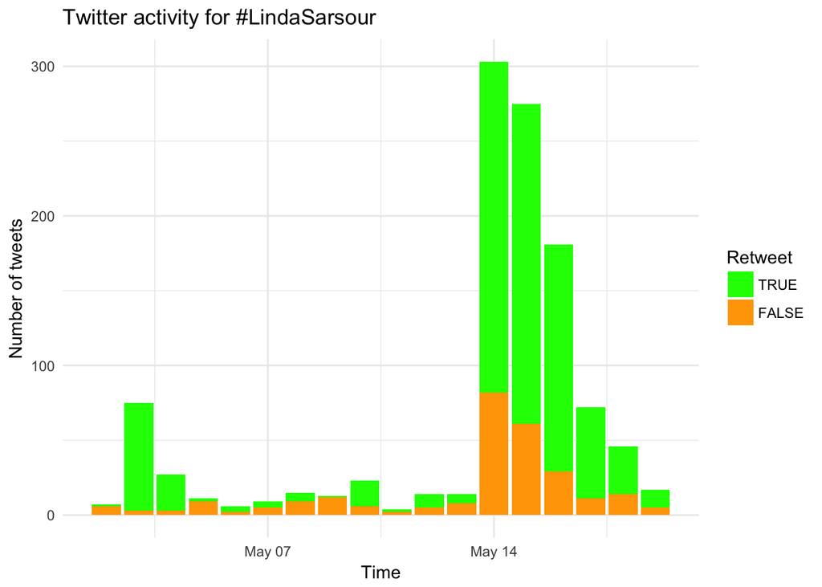

Between May 2 to May 18, a period of sixteen days, 907 users tweeted 1,128 posts using #LindaSarsour. On most days, there were less than 50 tweets using the hashtag. However, there is a spike of over 300 tweets using the hashtag on May 14 when the [U.S. Embassy was officially opened in Jerusalem and Israeli forces killed dozens of Palestinian protestors in Gaza and the West Bank](https://www.theguardian.com/world/live/2018/may/14/israeli-troops-kill-palestinians-protesting-against-us-embassy-move-to-jerusalem-live-updates). Most of the Twitter activity on and following May 14 are retweets.

### Hashtag Analysis

I next look at the hashtags that are simultaneously used with #LindaSarsour by trolls to understand the main topics of online attacks. I divide the analysis to before and after May 14 to track changes in the hashtags.

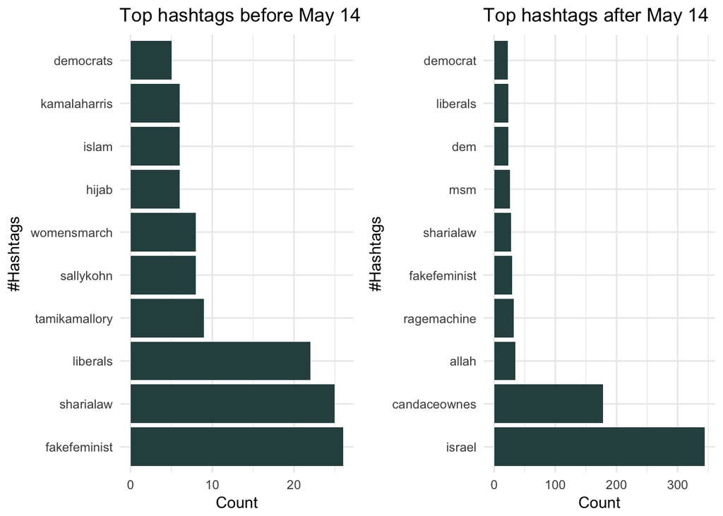

Before May 14, the hashtags most commonly used with #LindaSarsour by trolls are #FakeFeminist and #ShariaLaw. This suggest that on any given day, trolls mainly post tweets that aim to delegitimize her voice and activism. On and after May 14, these hashtags are overtaken by #Israel and #CandaceOwnes. This suggests trolls are trumpeting Candace Owens’ attack on Linda for speaking out against the killing of Palestinians by Israeli troops. Candace Owen is an African American and [a former target of racist trolls who came out as a conservative in 2017](https://mic.com/articles/189097/naacp-leader-who-defended-candace-owens-from-racist-trolls-shocked-to-learn-shes-conservative-now#.DH7kGpWKr).

### Text Analysis

This interpretation of the hashtags is supported by a text analysis of the tweets. The figure below visualizes the relationship of words in troll tweets. The dark red lines in the word network shows that trolls are celebrating the May 14 events. The trolls are also delighted that another woman of color can be pitted against Linda. Overall, the word network illustrates that trolls use hateful language that are clearly intended to trigger fear of Islam (see: terrorist, Sharia law). There are also worrying trends of trolls using language to not only delegitimize Linda (see: anti-American), but also dehumanize her (see: cockroach).

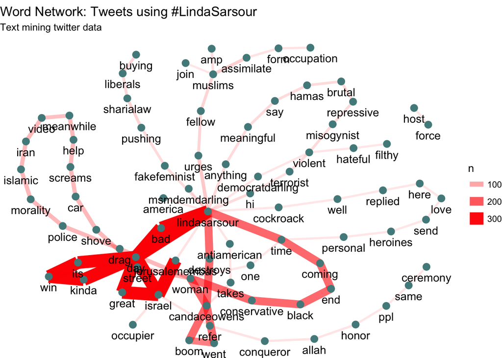

Such prejudiced online harassment begs the question what can be done? Should policymakers explicitly ban such hate postings? In Germany, the introduction of a new law regulating racist posts on Twitter and Facebook [unleashed a backlash among right-wing populists](http://www.spiegel.de/international/germany/german-populists-take-on-twitter-and-the-judiciary-a-1186233.html). In the age of Trump, such a law is unlikely to pass in the U.S. anytime soon.

So what are we to do? In a survey conducted in August 2017, [Statista found that 40% of adults in the U.S. who see a racist post on social media simply ignore it](https://www.statista.com/statistics/378629/reactions-to-racist-posts-on-social-media-us/). Following this, the most common action for [adults (31%) was to just unfollow or unfriend the poster](https://www.statista.com/statistics/378629/reactions-to-racist-posts-on-social-media-us/). The latest research on online racist behavior, however, suggests this is the wrong response.

In an experiment on Twitter, [Kevin Munger](https://doi.org/10.1007/s11109-016-9373-5) demonstrates individual actors have the power to reduce prejudiced behavior online by signaling what is not socially acceptable behavior. In Munger’s study, White male users on Twitter who tweeted a racial slur are simply tweeted back:

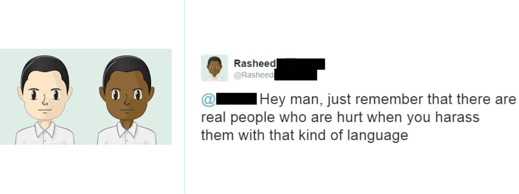

*source: Munger 2016*

In the following month, the White males who received this tweet from another White male with a high number of Twitter followers significantly reduced their racist online behavior. The study shows that an individual that is perceived as an in-group member with social status can reduce the racist online behavior of another person with a simple action.

Munger goes on to argue not responding to a hate post legitimizes the racist viewpoint and allows racist online behaviors to be seen as a social norm. So as the saying goes, if you see something, say something.

### User Analysis

In order to act on this lesson from the Munger study, it is important to know who are the people harassing Linda on Twitter. I first look at how the trolls using the hashtag #LindaSarsour describe themselves in their profiles. The results are displayed in the following word cloud:

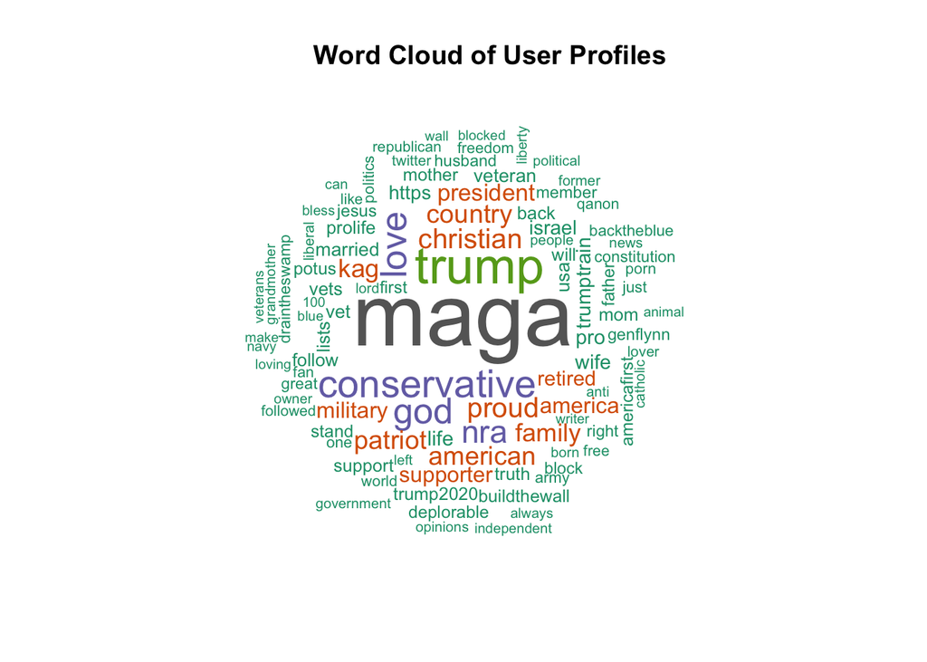

Unsurprisingly, there are a lot of Trump supporters as evidenced by the words Trump, MAGA (Make America Great Again) and KAG (Keep America Great). Many also identify themselves as conservatives, Christians, patriots, retirees as well as supporters of the military and NRA (National Rifle Association).

Next I identify the most influential troll among the users of the hashtag #LindaSarsour. The following graphs show the top 10 users by their follower count and retweet count.

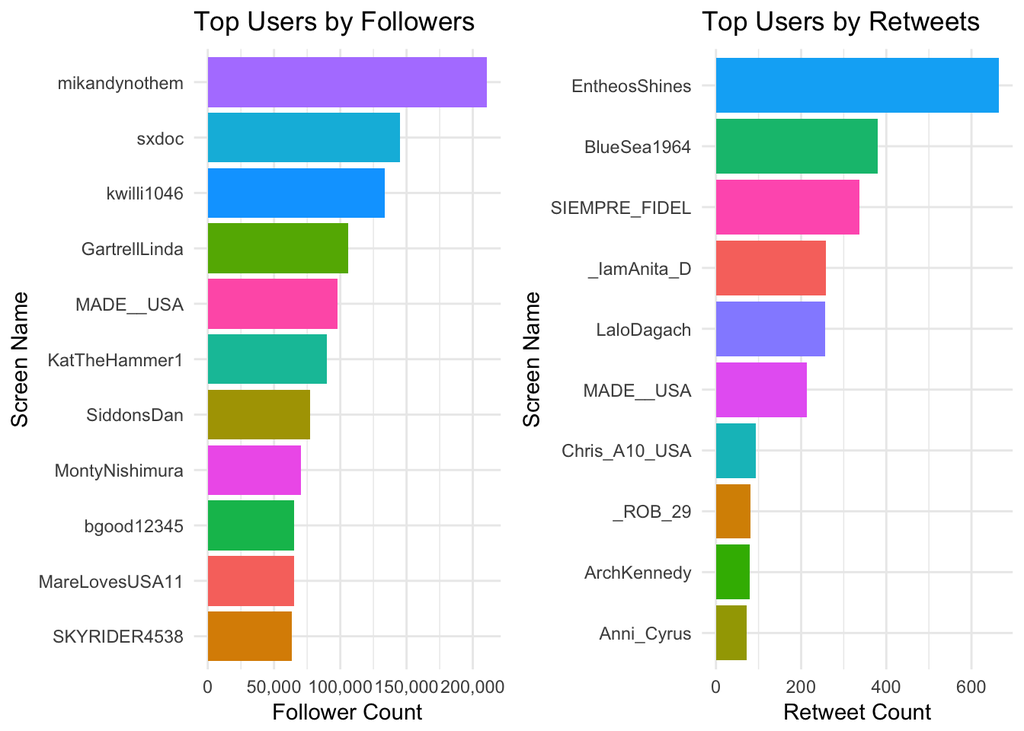

### Social Network Analysis

For a more nuanced view, I also undertake a social network analysis of retweets. The following figure maps the relationship and interactions between users when a post with the hashtag #LindaSarsour is retweeted. The screen names printed on the Retweet Network are users with a high degree of relationship with other users in terms of retweets.

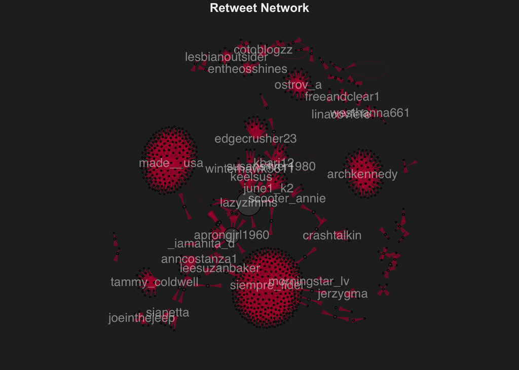

### Influential Trolls

When combining the users in the top 10 follower, top 10 retweet and Retweet Network map, I identify the following 43 users as very influential trolls.

```
##  [1] "_iamanita_d"     "_rob_29"         "anncostanza1"
##  [4] "anni_cyrus"      "aprongirl1960"   "archkennedy"
##  [7] "bgood12345"      "bluesea1964"     "chris_a10_usa"
## [10] "cotoblogzz"      "crashtalkin"     "edgecrusher23"
## [13] "entheosshines"   "freeandclear1"   "gartrelllinda"
## [16] "jerzygma"        "joeinthejeep"    "june1_k2"
## [19] "katthehammer1"   "kbari12"         "keelsus"
## [22] "kwilli1046"      "lalodagach"      "lazyzimms"
## [25] "leesuzanbaker"   "lesbianoutsider" "linacovfefe"
## [28] "made__usa"       "marelovesusa11"  "mikandynothem"
## [31] "montynishimura"  "morningstar_lv"  "ostrov_a"
## [34] "scooter_annie"   "sianetta"        "siddonsdan"
## [37] "siempre_fidel"   "skyrider4538"    "susansilver1980"
## [40] "sxdoc"           "tammy_coldwell"  "westhanna661"
## [43] "winterhawk5611"
```

### Take Action!

To help reduce prejudiced online behavior against Linda Sarsour, I recommend responding to the posts made by these influential trolls. Not acting and speaking up against prejudice posts online only allows such behaviors to become the norm. To make the task easier, I’ve created the following cheat sheet. These 5 trolls appear more than once in the follower count, retweet count and retweet network lists of most influential trolls.

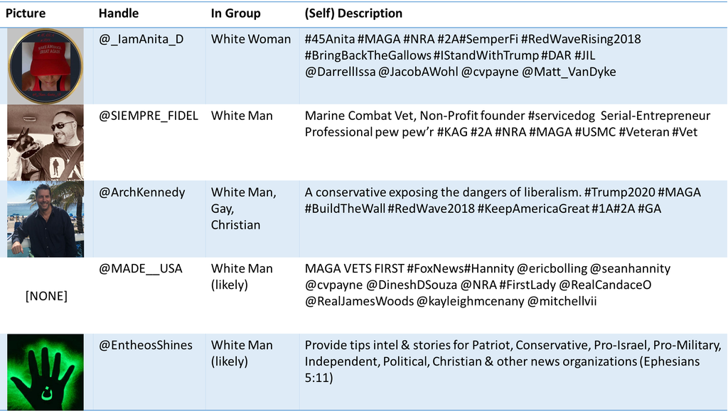

#### Bibliography

Ahmad, H., Amann, M., Röbel, S., & Rosenbach, M. (2018, January 4). Germany’s New Hate Speech Law: Populists Fight for Their Right to Racism. Retrieved from http://www.spiegel.de/international/germany/german-populists-take-on-twitter-and-the-judiciary-a-1186233.html

Alcorn, C. (2018, April 28). NAACP leader who defended Candace Owens from racist trolls schoked to learn she’s conservative now. Mic. Retrieved from https://mic.com/articles/189097/naacp-leader-who-defended-candace-owens-from-racist-trolls-shocked-to-learn-shes-conservative-now#.DH7kGpWKr

Council on American-Islamic Relations (CAIR). (2017, July 7). Press Release: CAIR Calls for #IStandWithLinda “Push Back” Against Smear Campaign Targeting Linda Sarsour. Retrieved from https://www.prnewswire.com/news-releases/cair-calls-for-istandwithlinda-push-back-against-smear-campaign-targeting-linda-sarsour-300484682.html

Duggan, M. (2017). Online Harrassment 2017. Retrieved from http://assets.pewresearch.org/wp-content/uploads/sites/14/2017/07/10151519/PI_2017.07.11_Online-Harassment_FINAL.pdf

Holpuch, A., & Weaver, M. (2018, May 14). Israeli forces kill dozens of Palestinians in protests as US embassy opens in Jerusalem – as it happened. The Guardian. Retrieved from https://www.theguardian.com/world/live/2018/may/14/israeli-troops-kill-palestinians-protesting-against-us-embassy-move-to-jerusalem-live-updates

Munger, K. (2017). Tweetment Effects on the Tweeted: Experimentally Reducing Racist Harassment. Political Behavior, 39(3), 629–649. https://doi.org/10.1007/s11109-016-9373-5

Prachi, G. (2017, August 9). The Demonization of Linda Sarsour. Jezebel. Retrieved from https://jezebel.com/the-demonization-of-linda-sarsour-1797537513

Statista. (2017). Reactions to racist posts on social media in the U.S. 2017. Retrieved May 20, 2018, from https://www.statista.com/statistics/378629/reactions-to-racist-posts-on-social-media-us/